# Relative deprivation in Trafford

Last updated: 18 December 2025

This report explores the [2025 English Indices of Deprivation](https://www.gov.uk/government/statistics/english-indices-of-deprivation-2025) for Trafford. It compares Trafford with other local authorities in Greater Manchester (GM) and similar authorities in England using the rank of average score, tracks relative change in ranking between 2019 and 2025, indicates the percentage of Lower-layer Super Output Areas (LSOAs) in the most deprived decile, identifies the most deprived small areas and present the disparities within Trafford.

## Key findings

- Trafford is ranked 201 on the 2025 Index of Multiple Deprivation (IMD) out of 296 local authority districts in England where 1 is the most deprived and 296 is the least deprived. Trafford ranked 191 out of 317 local authorities in 2019.
- Trafford decreased in relative deprivation between 2019 and 2025 on the IMD.
- The lowest rank of Trafford was on the Living environment deprivation domain ranking 79 among local authorities in 2025, the largest change from 2019 when Trafford ranked 131. These may be due to the change in datasets and methodology to produce the Living enviromnent domain.
- The proportion of Trafford’s Lower-layer Super Output areas in the most deprived 10% nationally was 4.3% on the 2025 IMD. This represents a decrease of 0.8% since the 2019 IMD.
- Trafford was ranked the least deprived of all Greater Manchester local authorities in the 2025 IMD and across all domains except living Environment where ranked 4th least deprived and Barriers to Housing & Services and the Income Deprivation Affecting Older People sub-domain where Trafford ranked 2nd least deprived.
- Trafford was ranked the second least deprived of all 15 CIPFA similar authorities in the 2025 IMD and 1st to 3rd least deprived in the other domains except for the Living Environment where is the 2nd most deprived, Crime where is 7th least deprived and Income Deprivation Affecting Older people subdomain where is 7th least deprived.
- Trafford ranked in the middle out of the 16 NHS peer group authorities in the 2025 IMD and ranged from 3rd less deprived to 5th most deprived on the other domains and subdomains.
- Trafford 017E in Bucklow-St Martins ward is the most deprived LSOA in Trafford in the IMD ranking 382 out of 33,755 LSOAs in England. It sits within the 5% most deprived LSOAs nationally for Income, Employment, Health & Disability, Crime and both subdomains Income Deprivation Affecting Children and Income Deprivation Affecting Older People.
- Trafford 019E in Manor ward and Trafford 017E in Bucklow-St Martins ward rank 699 and 712 respectively out of 33,755 LSOAs nationally on the Income Deprivation Affecting Children sub-domain with with more than 80% of children aged 0 to 15 living in income deprived families.
- Trafford 001G in Gorse Hill & Cornbrook ward rank 699 and 712 out of 33,755 LSOAs nationally on the Income Deprivation Affecting Older people sub-domain with with more than 96% of all those aged 60 or over experiencing income deprivation.
- Trafford 017E in in Bucklow-St Martins ward rank 196 out of 33,755 LSOAs nationally on the Employment domain with 41.5% of working-age residents involuntarily excluded from the labour market.

## Background

Relative deprivation is measured using 54 indicators which are grouped across seven different domains:

- **Income** - the proportion of the population experiencing deprivation relating to low income, including those people-out-of-work, and those who have low earnings
- **Employment** - the proportion of the working age population in an area involuntarily excluded from the labour market including unemployment, sickness or disabiliry, or caring responsabilities.
- **Education, Skills and Training** - the lack of attainment and skills in the local population
- **Health and Disability** - the risk of premature death and the impairment of quality of life through poor physical or mental health
- **Crime** - the risk of personal and material victimisation at a local level
- **Barriers to Housing and Services** - the physical and financial accessibility of housing and local services
- **Living Environment** - the quality of the local environment

Each domain is combined and weighted to create the **Index of Multiple Deprivation** (IMD), an overall measure of relative deprivation.

A further 2 supplementary indices of income deprivation are also provided:

- **Income Deprivation Affecting Children Index** - the proportion of all children aged 0 to 15 living in income deprived families
- **Income Deprivation Affecting Older People Index** - the proportion of all those aged 60 or over who experience income deprivation

In this report, Trafford is compared with the other 9 Greater Manchester local authorities, the 15 [CIPFA Nearest Neighbours](https://www.cipfa.org/services/cipfastats/nearest-neighbour-model) and the 15 [NHS England Near Neighbour Peer Group](https://github.com/NHSDigital/ASC_LA_Peer_Groups) local authorities for Trafford.

#### Please note

- New datasets, methodologies and geographies have been used to produce the IoD25, meaning outputs are less directly comparable to previous Indices.
- The number of component indicators used to produce the indices has changed from 39 in 2019 to 54 in 2025.
- The Indices of Deprivation measure *relative* deprivation so a change in rank between 2019 and 2015 releases does not necessarily indicate a change in *absolute* levels of deprivation.
- Full information on the indices’s methodology and dataset can be found in the [Technical Report](https://assets.publishing.service.gov.uk/media/68ff59c80f801e57b5bef907/ID_2025_Technical_Report.pdf)

#### Further resources

- A web application which interactively visualises the proportion of LSOAs in the most deprived decile and the spatial distribution of relative deprivation for every local authority district in England is available [here](https://trafforddatalab.shinyapps.io/local_deprivation/).
- A collection of outputs related to the English index of deprivation can be found [here](https://www.trafforddatalab.io/deprivation.html)

## Index of Multiple Deprivation

Trafford is ranked 201 out of 296 local authority districts in England on the average 2025 Index of Multiple Deprivation (IMD) score, where a rank of 1 is the most deprived. Trafford’s relative position has raised from 191 out of 317 local authorities in 2019. In GM, 6 out of 10 authorities including Trafford reported a decrease in relative deprivation rankings since 2019. Trafford remains the least deprived local authority in Greater Manchester.

Half of CIPFA neighbours raised their relative position in ranking among other local authorities becoming relatively less deprived in 2025 compared to 2019. Around 30% of the NHS peer authorities become relatively less deprived in 2025 compared to 2019.

Click the tabs below for:

#### GM

#### Relative change in rank of average IMD score, GM authorities

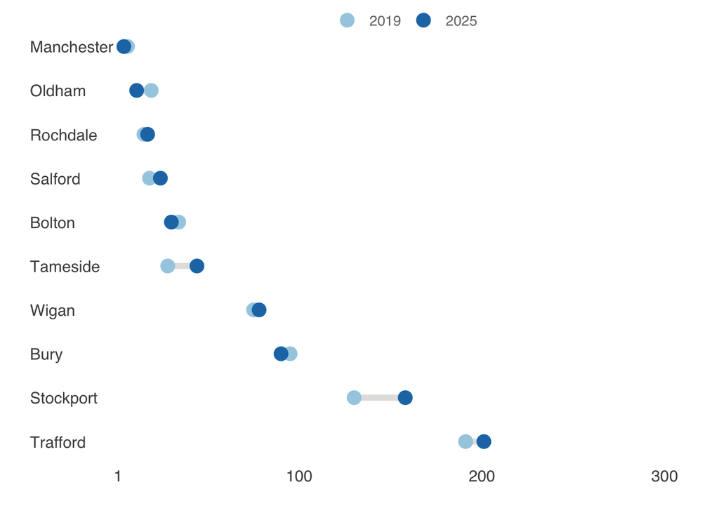

| Local authority | 2019 | 2025 | Change |
| --- | --- | --- | --- |
| Manchester | 6 | 4 | -2 |
| Oldham | 19 | 11 | -8 |
| Rochdale | 15 | 17 | 2 |
| Salford | 18 | 24 | 6 |
| Bolton | 34 | 30 | -4 |
| Tameside | 28 | 44 | 16 |
| Wigan | 75 | 78 | 3 |
| Bury | 95 | 90 | -5 |
| Stockport | 130 | 158 | 28 |
| Trafford | 191 | 201 | 10 |

1 is most deprived  
Source: English Indices of Deprivation, MHCLG | @traffordDataLab

#### CIPFA

#### Relative change in rank of average IMD score, CIPFA statistical neighbours

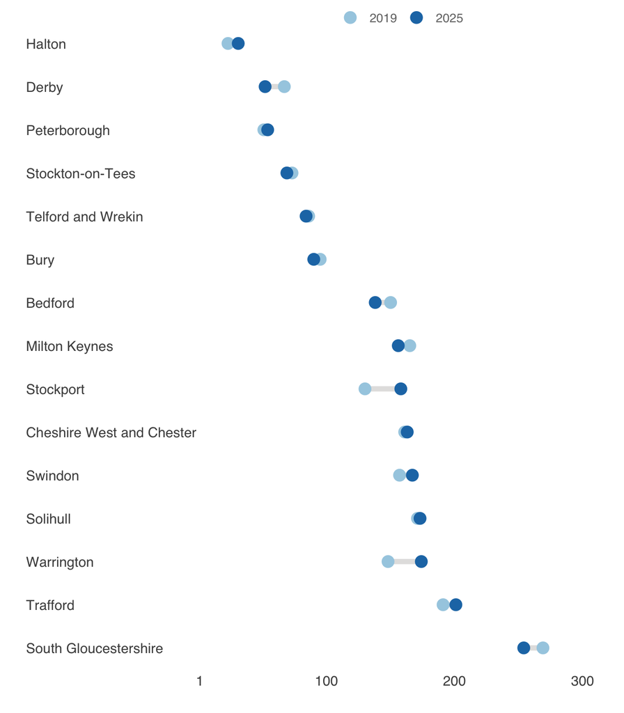

| Local authority | 2019 | 2025 | Change |
| --- | --- | --- | --- |
| Halton | 23 | 31 | 8 |
| Derby | 67 | 52 | -15 |
| Peterborough | 51 | 54 | 3 |
| Stockton-on-Tees | 73 | 69 | -4 |
| Telford and Wrekin | 86 | 84 | -2 |
| Bury | 95 | 90 | -5 |
| Bedford | 150 | 138 | -12 |
| Milton Keynes | 165 | 156 | -9 |
| North Northamptonshire | NA | 157 | NA |
| Stockport | 130 | 158 | 28 |
| Cheshire West and Chester | 161 | 163 | 2 |
| Swindon | 157 | 167 | 10 |
| Solihull | 171 | 173 | 2 |
| Warrington | 148 | 174 | 26 |
| Trafford | 191 | 201 | 10 |
| South Gloucestershire | 269 | 254 | -15 |

1 is most deprived  
Source: English Indices of Deprivation, MHCLG | @traffordDataLab

#### NHS Peers

#### Relative change in rank of average IMD score, NHS Near Neighbour peer group

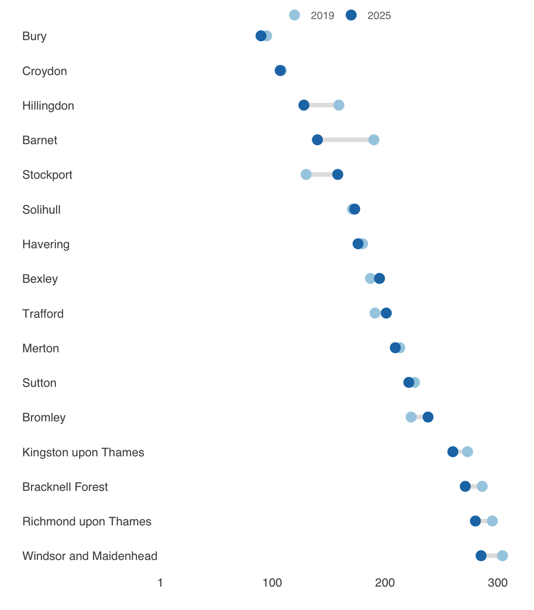

| Local authority | 2019 | 2025 | Change |
| --- | --- | --- | --- |
| Bury | 95 | 90 | -5 |
| Croydon | 108 | 107 | -1 |
| Hillingdon | 159 | 128 | -31 |
| Barnet | 190 | 140 | -50 |
| Stockport | 130 | 158 | 28 |
| Solihull | 171 | 173 | 2 |
| Havering | 180 | 176 | -4 |
| Bexley | 187 | 195 | 8 |
| Trafford | 191 | 201 | 10 |
| Merton | 213 | 209 | -4 |
| Sutton | 226 | 221 | -5 |
| Bromley | 223 | 238 | 15 |
| Kingston upon Thames | 273 | 260 | -13 |
| Bracknell Forest | 286 | 271 | -15 |
| Richmond upon Thames | 295 | 280 | -15 |
| Windsor and Maidenhead | 304 | 285 | -19 |

1 is most deprived  
Source: English Indices of Deprivation, MHCLG | @traffordDataLab

The proportion of Trafford’s LSOAs ranked in the 1st decile or 10% most deprived in England was 4.3% (6 out of 139) in 2025. This represents a relative decrease compared to 2019 when 5.1% (7 out of 138) of LSOAs were ranked within the 1st decile. However, the proportion of LSOAs in Trafford in the bottom decile is much lower than other GM local authorities, 3rd lowest among CIPFA neighbours and 4th highest among NHS peers.

Click the tabs below for:

#### GM

#### Change in percentage of LSOAs in 1st decile of IMD, GM authorities

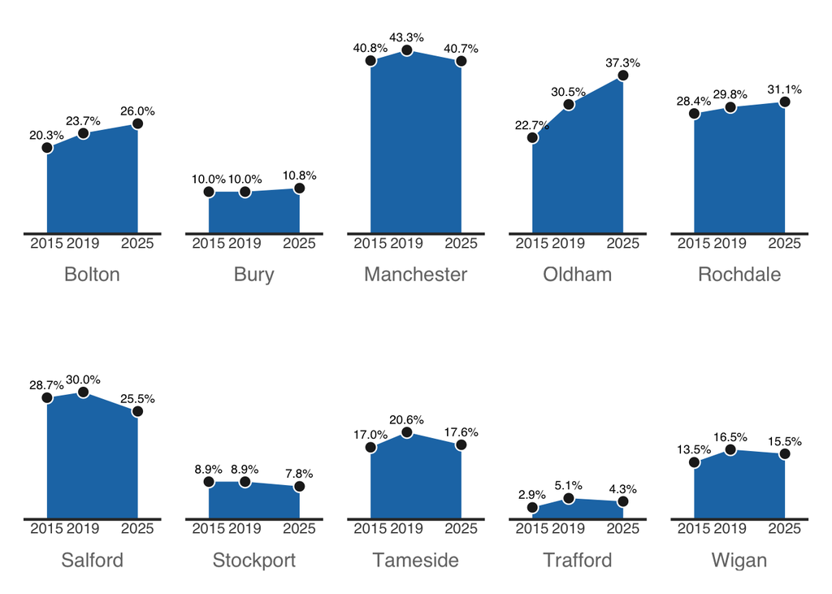

###### Source: English Indices of Deprivation, MHCLG | @traffordDataLab

#### CIPFA

#### Change in percentage of LSOAs in 1st decile of IMD, CIPFA statistical neighbours

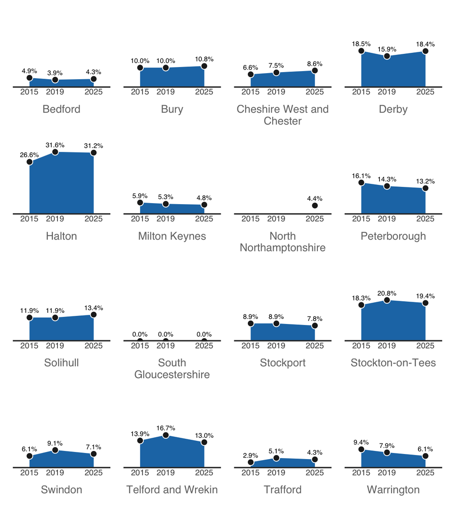

###### Source: English Indices of Deprivation, MHCLG | @traffordDataLab

#### NHS Peers

#### Change in percentage of LSOAs in 1st decile of IMD, NHS Near Neighbour peer group

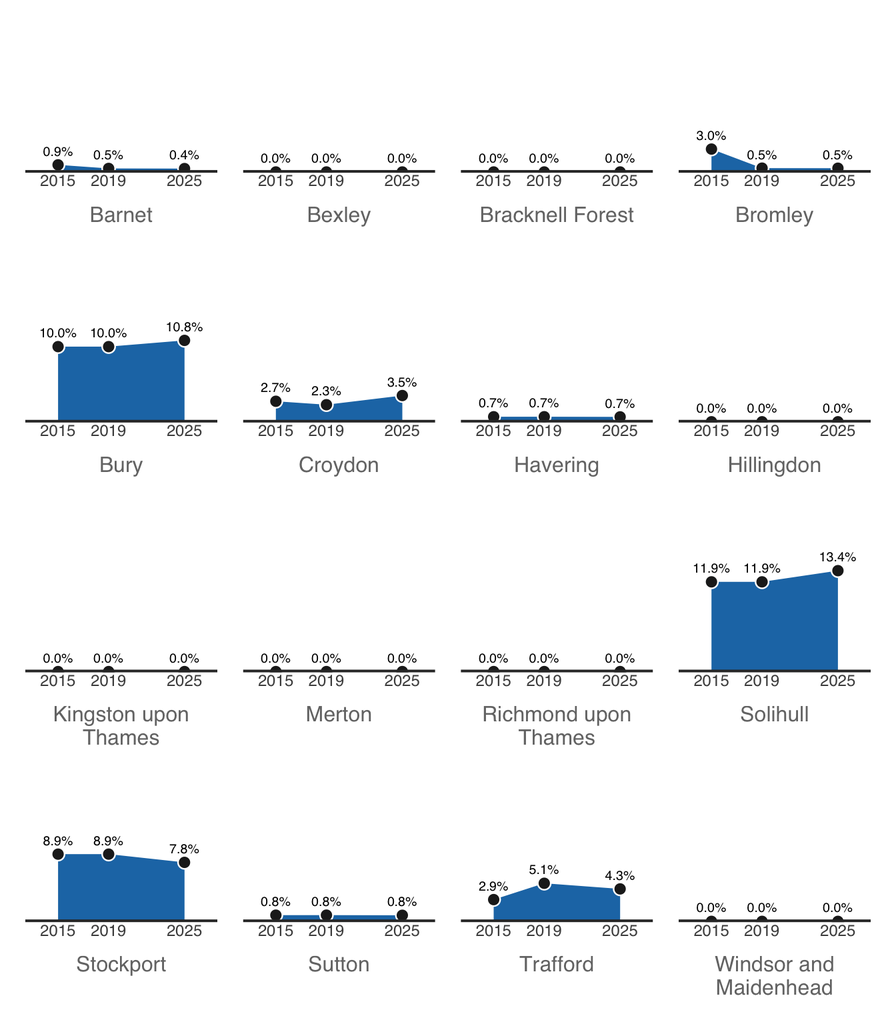

###### Source: English Indices of Deprivation, MHCLG | @traffordDataLab

2 LSOAs in Bucklow-St Martins, 1 in Old Trafford, 2 in Manor and 1 in Longford ward were amongst the 10% most deprived LSOAs in England in 2025.

#### Index of Multiple Deprivation 2025, LSOAs in Trafford

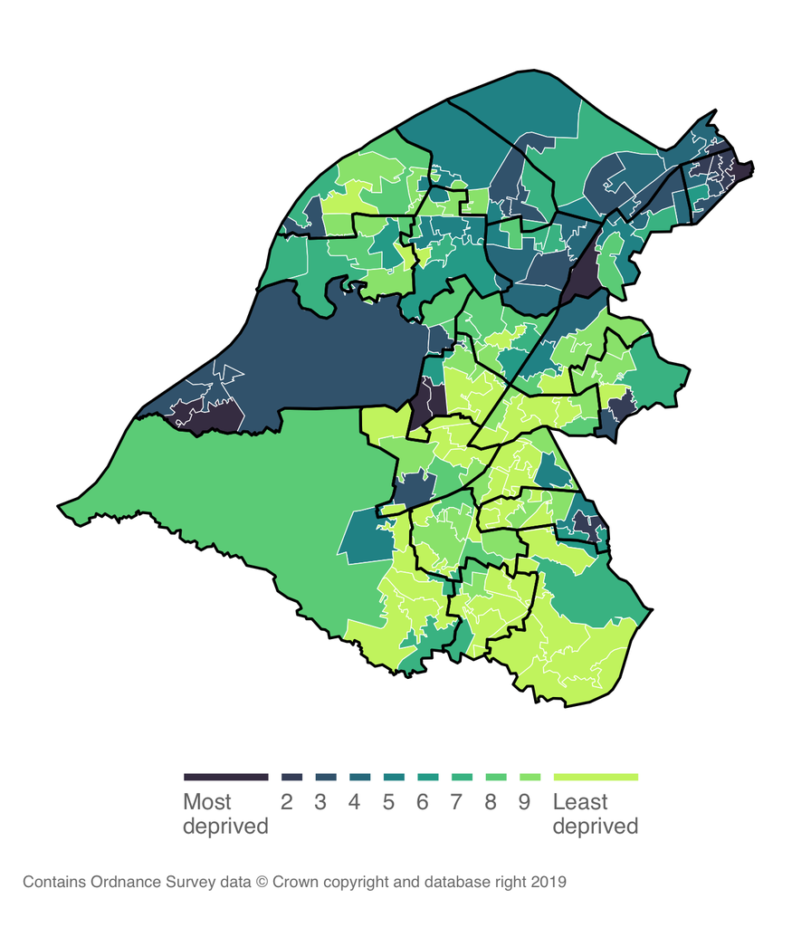

| LSOA | Ward | Decile | Rank |
| --- | --- | --- | --- |
| E01006108 | Bucklow-St Martins | 1 | 382 |
| E01006105 | Bucklow-St Martins | 1 | 895 |
| E01006109 | Old Trafford | 1 | 1,026 |
| E01006168 | Manor | 1 | 1,543 |
| E01006167 | Manor | 1 | 2,767 |
| E01006144 | Longford | 1 | 3,219 |

Source: English Indices of Deprivation (2025), MHCLG. | @traffordDataLab

#### Index of Multiple Deprivation 2025, LSOAs in Trafford

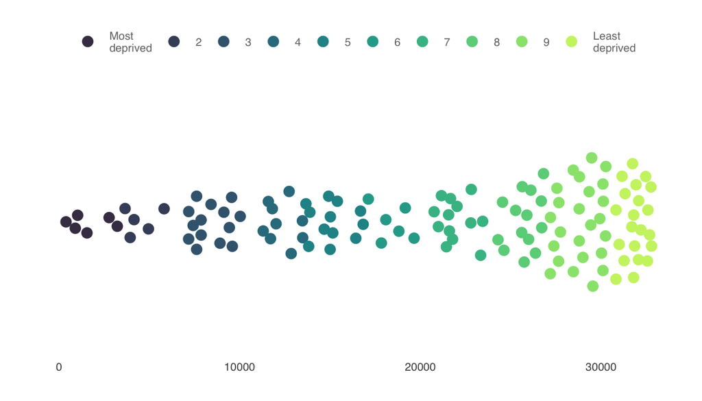

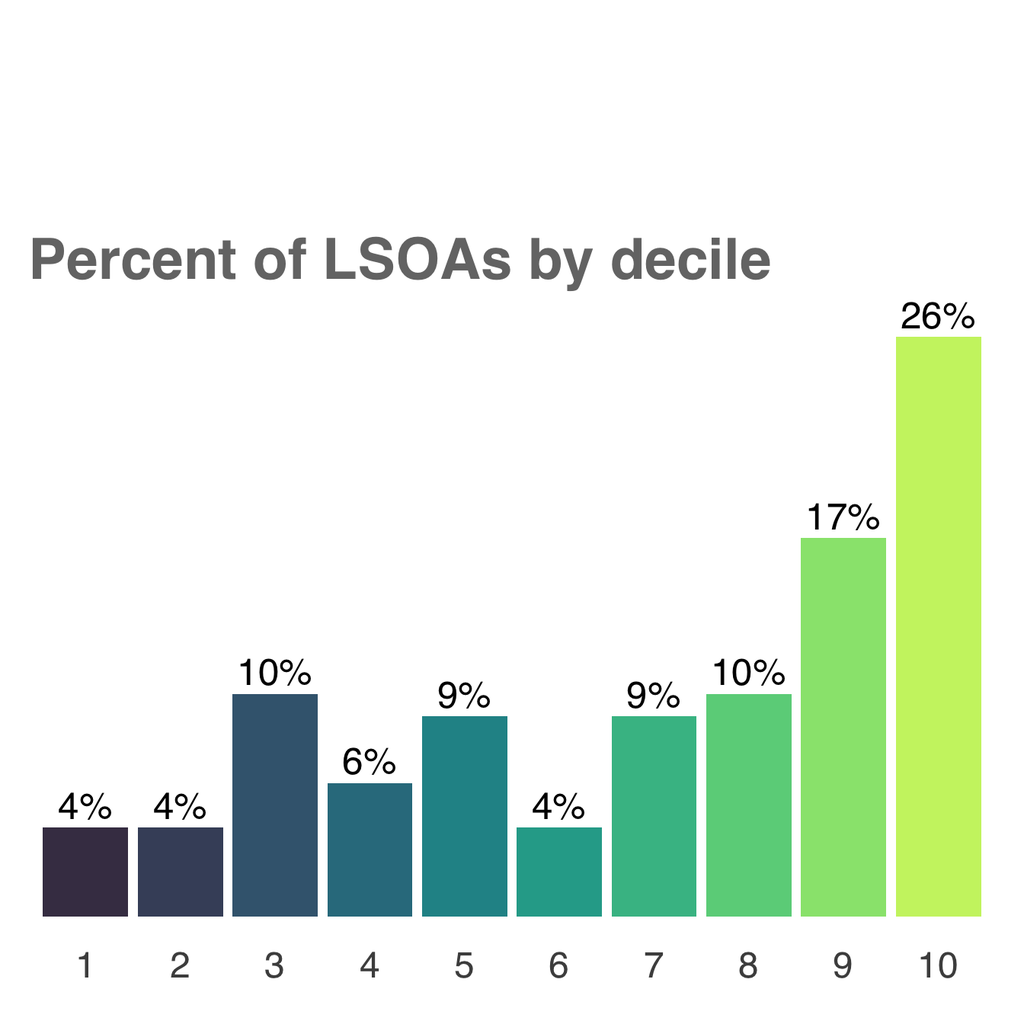

Source: English Indices of Deprivation (2025), MHCLG | @traffordDataLab

The difference between the rank of the most deprived LSOA (382) and the least deprived LSOA (33744) on the Index of Multiple Deprivation is 33362

18 % of the LSOAs in Trafford are among the 3 most deprived deciles in England, 53.2 % of the LSOAs in Trafford are among the 3 least deprived deciles in England

## Income

The Income domain measures the proportion of the population experiencing deprivation relating to low income, including those people-out-of-work, and those who have low earnings.

Trafford is ranked 189 out of 296 local authorities in England on the average 2025 Income domain score. Trafford’s relative position was 166 out of 317 local authorities in 2019.

Click the tabs below for:

#### GM

#### Relative change in rank of average Income score, GM authorities

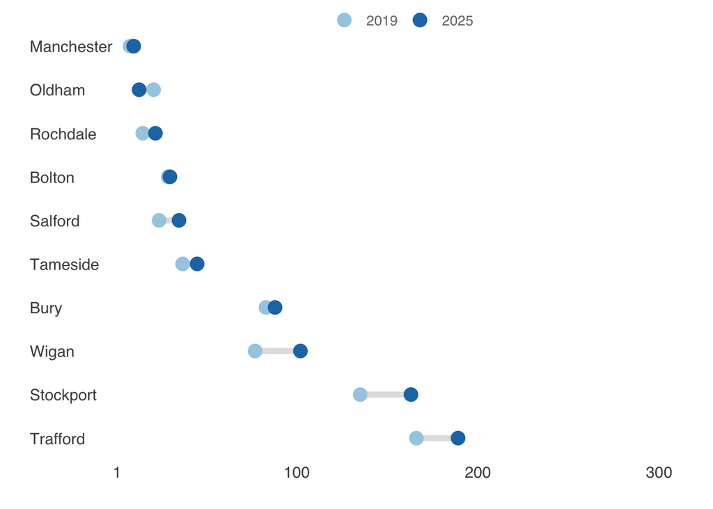

| Local authority | 2019 | 2025 | Change |
| --- | --- | --- | --- |
| Manchester | 8 | 10 | 2 |
| Oldham | 21 | 13 | -8 |
| Rochdale | 15 | 22 | 7 |
| Bolton | 29 | 30 | 1 |
| Salford | 24 | 35 | 11 |
| Tameside | 37 | 45 | 8 |
| Bury | 83 | 88 | 5 |
| Wigan | 77 | 102 | 25 |
| Stockport | 135 | 163 | 28 |
| Trafford | 166 | 189 | 23 |

The lowest the rank, the most deprivedSource: English Indices of Deprivation, MHCLG | @traffordDataLab

#### CIPFA

#### Relative change in rank of average Income score, CIPFA statistical neighbours

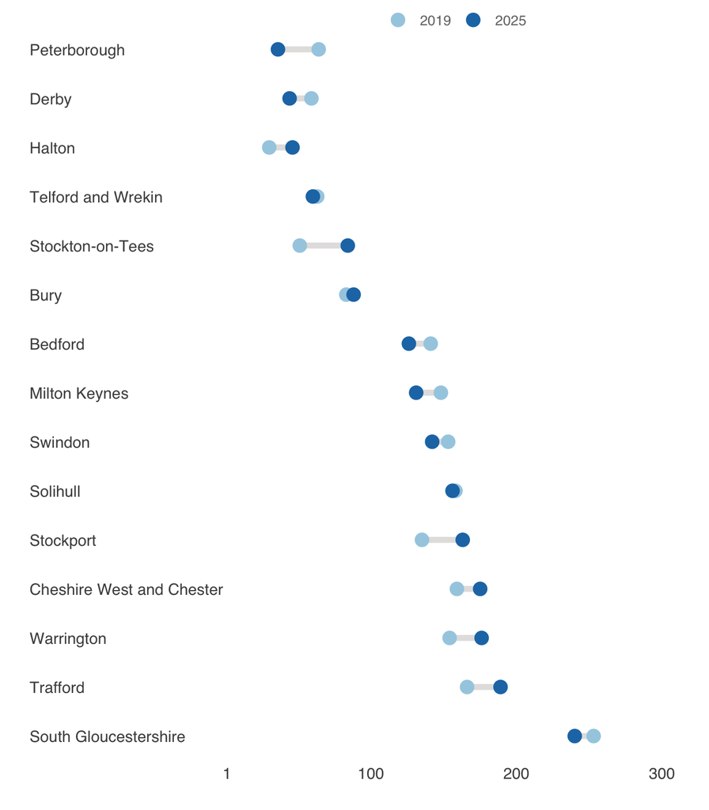

| Local authority | 2019 | 2025 | Change |
| --- | --- | --- | --- |
| Peterborough | 64 | 36 | -28 |
| Derby | 59 | 44 | -15 |
| Halton | 30 | 46 | 16 |
| Telford and Wrekin | 63 | 60 | -3 |
| Stockton-on-Tees | 51 | 84 | 33 |
| Bury | 83 | 88 | 5 |
| Bedford | 141 | 126 | -15 |
| Milton Keynes | 148 | 131 | -17 |
| North Northamptonshire | NA | 136 | NA |
| Swindon | 153 | 142 | -11 |
| Solihull | 158 | 156 | -2 |
| Stockport | 135 | 163 | 28 |
| Cheshire West and Chester | 159 | 175 | 16 |
| Warrington | 154 | 176 | 22 |
| Trafford | 166 | 189 | 23 |
| South Gloucestershire | 253 | 240 | -13 |

The lowest the rank, the most deprivedSource: English Indices of Deprivation, MHCLG | @traffordDataLab

#### NHS Peers

#### Relative change in rank of average Income score, NHS Near Neighbour peer group

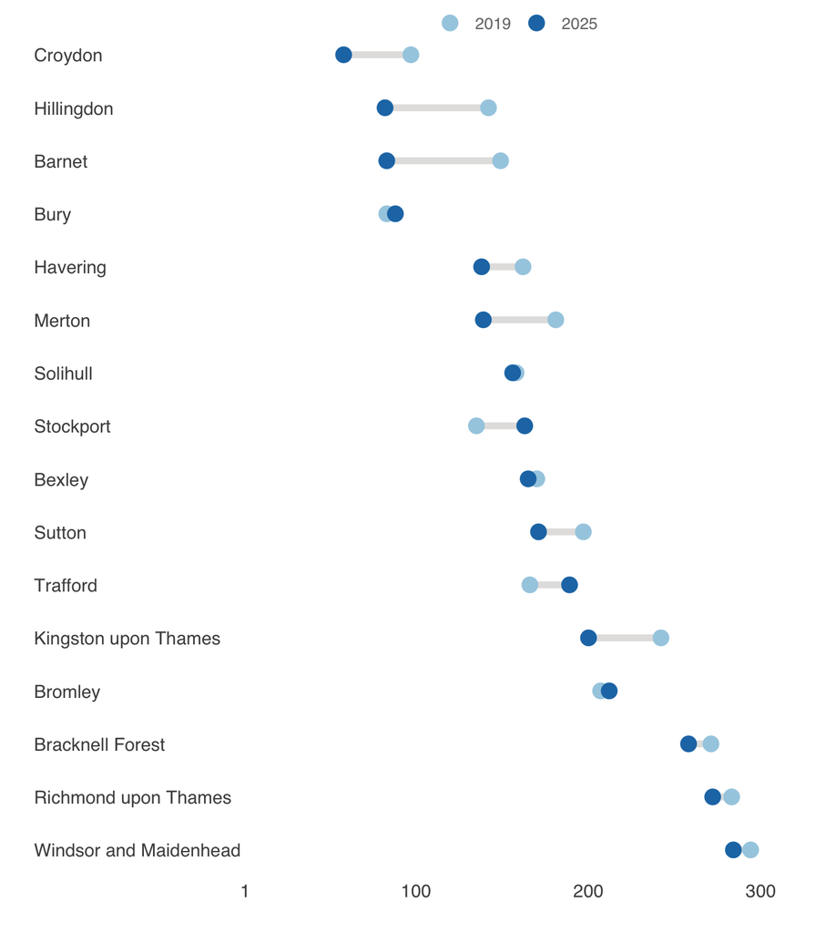

| Local authority | 2019 | 2025 | Change |
| --- | --- | --- | --- |
| Croydon | 97 | 58 | -39 |
| Hillingdon | 142 | 82 | -60 |
| Barnet | 149 | 83 | -66 |
| Bury | 83 | 88 | 5 |
| Havering | 162 | 138 | -24 |
| Merton | 181 | 139 | -42 |
| Solihull | 158 | 156 | -2 |
| Stockport | 135 | 163 | 28 |
| Bexley | 170 | 165 | -5 |
| Sutton | 197 | 171 | -26 |
| Trafford | 166 | 189 | 23 |
| Kingston upon Thames | 242 | 200 | -42 |
| Bromley | 207 | 212 | 5 |
| Bracknell Forest | 271 | 258 | -13 |
| Richmond upon Thames | 283 | 272 | -11 |
| Windsor and Maidenhead | 294 | 284 | -10 |

The lowest the rank, the most deprivedSource: English Indices of Deprivation, MHCLG | @traffordDataLab

Click the tabs below for:

#### GM

#### Change in percentage of LSOAs in 1st decile of Income domain, GM authorities

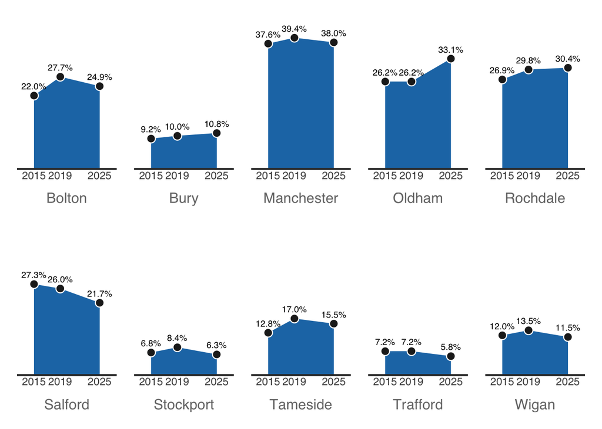

###### Source: English Indices of Deprivation, MHCLG | @traffordDataLab

#### CIPFA

#### Change in percentage of LSOAs in 1st decile of Income domain, CIPFA statistical neighbours

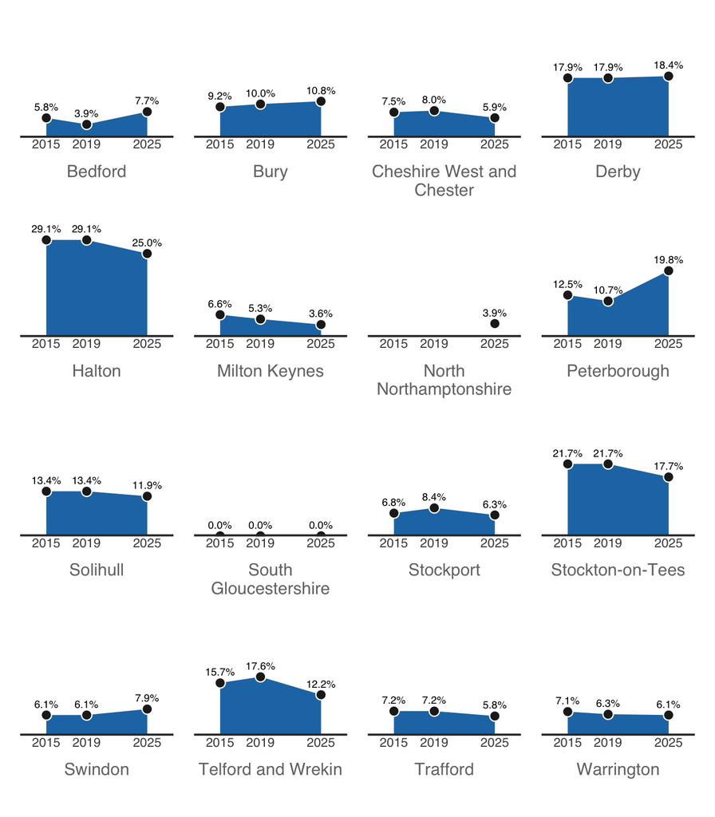

###### Source: English Indices of Deprivation, MHCLG | @traffordDataLab

#### NHS Peers

#### Change in percentage of LSOAs in 1st decile of Income domain, NHS Near Neighbour peer group

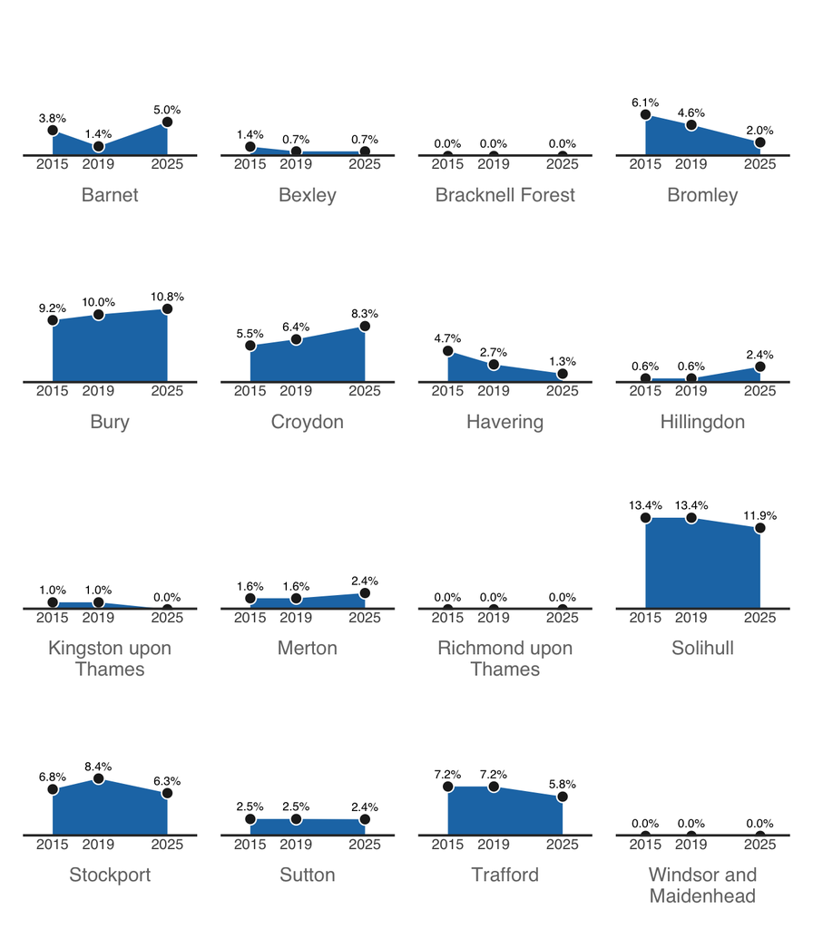

###### Source: English Indices of Deprivation, MHCLG | @traffordDataLab

Trafford 017E in Bucklow-St Martins ward 256 out of 33,755 LSOAs nationally with 68.5% of residents experiencing deprivation relating to low income, including those people-out-of-work, and those who have low earnings. In 2019, the same LSOA was ranked 487 out of 32,844 LSOAs nationally with 39.1% of residents experiencing deprivation relating to low income.

#### Income domain 2025, LSOAs in Trafford

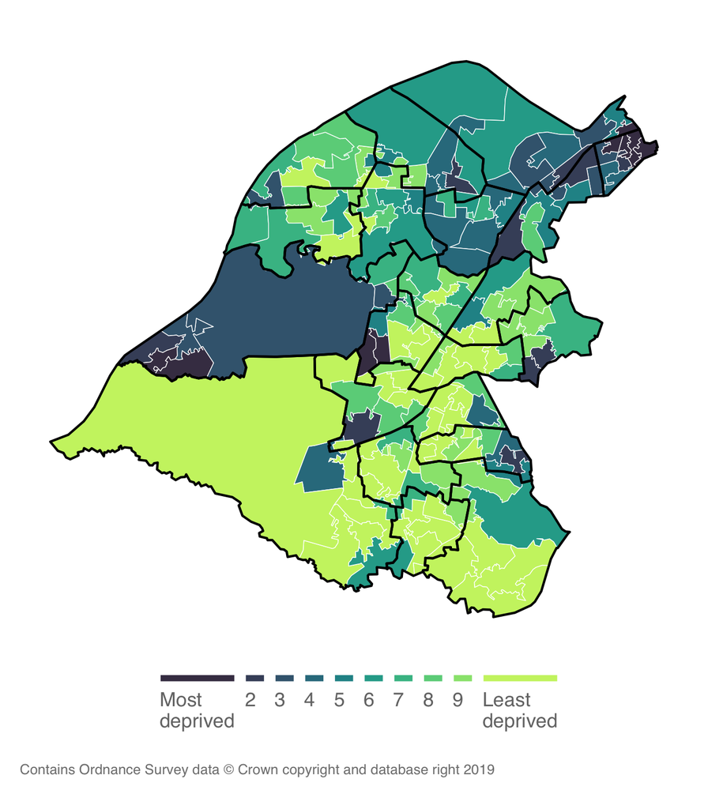

| LSOA | Ward | Decile | Rank |
| --- | --- | --- | --- |
| E01006108 | Bucklow-St Martins | 1 | 256 |
| E01006168 | Manor | 1 | 516 |
| E01006105 | Bucklow-St Martins | 1 | 680 |
| E01006109 | Old Trafford | 1 | 802 |
| E01006167 | Manor | 1 | 1,814 |
| E01006111 | Old Trafford | 1 | 2,260 |
| E01006112 | Old Trafford | 1 | 2,989 |
| E01034001 | Gorse Hill & Cornbrook | 1 | 3,260 |

Source: English Indices of Deprivation (2025), MHCLG | @traffordDataLab

#### Income deprivation 2025, LSOAs in Trafford

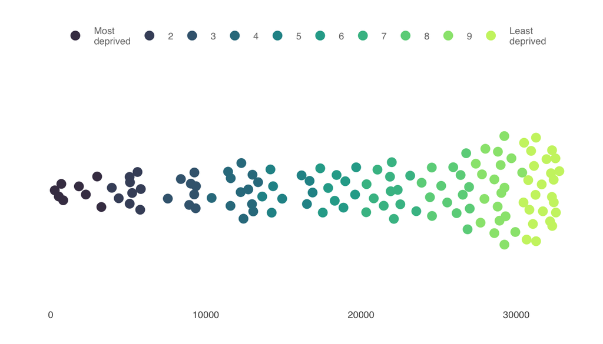

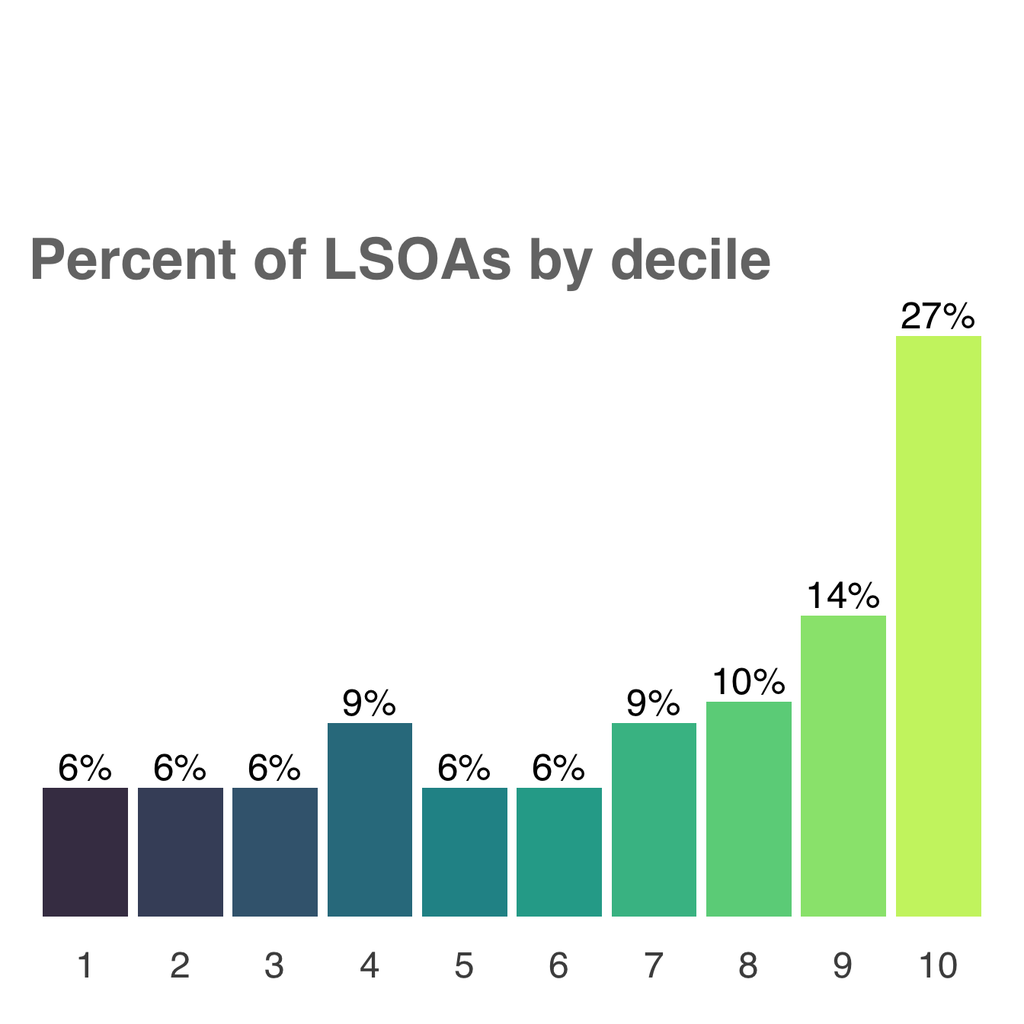

1 is most deprived  
Source: English Indices of Deprivation (2025), MHCLG | @traffordDataLab

The difference between the rank of the most deprived LSOA (256) and the least deprived LSOA (33729) on the Index of Multiple Deprivation is 33473

18 % of the LSOAs in Trafford are among the 3 most deprived deciles in England, 51.1 % of the LSOAs in Trafford are among the 3 least deprived deciles in England

## Employment

The Employment domain measures the proportion of the working age population in an area involuntarily excluded from the labour market.

Trafford is ranked 162 out of 296 local authorities in England on the average 2025 Employment domain score. Trafford’s relative position was 155 out of 317 local authorities in 2019.

Click the tabs below for:

#### GM

#### Relative change in rank of average Employment score, GM authorities

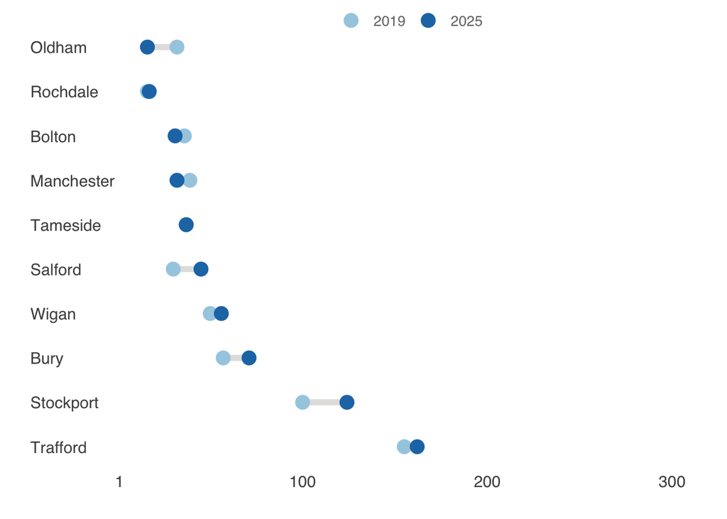

| Local authority | 2019 | 2025 | Change |
| --- | --- | --- | --- |
| Oldham | 32 | 16 | -16 |
| Rochdale | 16 | 17 | 1 |
| Bolton | 36 | 31 | -5 |
| Manchester | 39 | 32 | -7 |
| Tameside | 37 | 37 | 0 |
| Salford | 30 | 45 | 15 |
| Wigan | 50 | 56 | 6 |
| Bury | 57 | 71 | 14 |
| Stockport | 100 | 124 | 24 |
| Trafford | 155 | 162 | 7 |

Source: English Indices of Deprivation, MHCLG | @traffordDataLab

#### CIPFA

#### Relative change in rank of average Employment score, CIPFA statistical neighbours

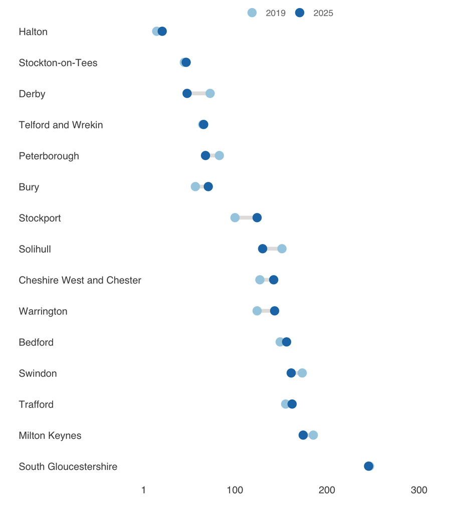

| Local authority | 2019 | 2025 | Change |
| --- | --- | --- | --- |
| Halton | 15 | 21 | 6 |
| Stockton-on-Tees | 45 | 47 | 2 |
| Derby | 73 | 48 | -25 |
| Telford and Wrekin | 65 | 66 | 1 |
| Peterborough | 83 | 68 | -15 |
| Bury | 57 | 71 | 14 |
| Stockport | 100 | 124 | 24 |
| Solihull | 151 | 130 | -21 |
| Cheshire West and Chester | 127 | 142 | 15 |
| Warrington | 124 | 143 | 19 |
| North Northamptonshire | NA | 155 | NA |
| Bedford | 149 | 156 | 7 |
| Swindon | 173 | 161 | -12 |
| Trafford | 155 | 162 | 7 |
| Milton Keynes | 185 | 174 | -11 |
| South Gloucestershire | 246 | 245 | -1 |

Source: English Indices of Deprivation, MHCLG | @traffordDataLab

#### NHS Peers

#### Relative change in rank of average Employment score, NHS Near Neighbour peer group

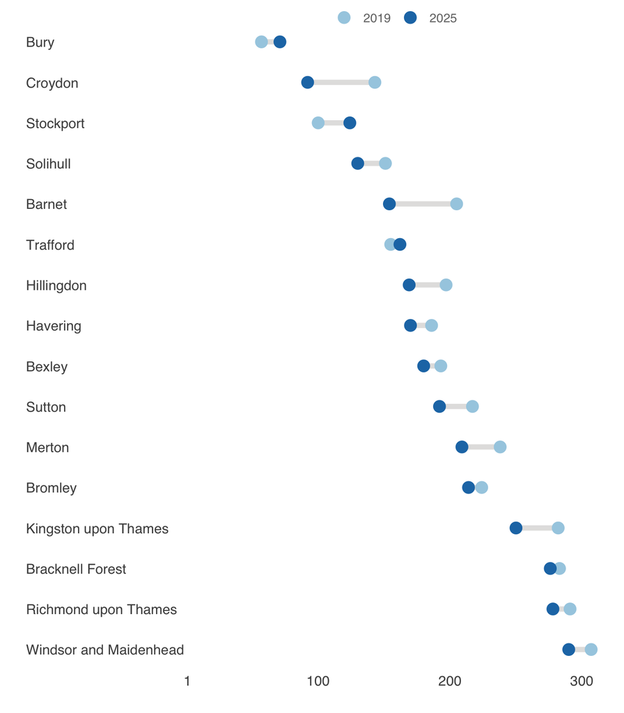

| Local authority | 2019 | 2025 | Change |
| --- | --- | --- | --- |
| Bury | 57 | 71 | 14 |
| Croydon | 143 | 92 | -51 |
| Stockport | 100 | 124 | 24 |
| Solihull | 151 | 130 | -21 |
| Barnet | 205 | 154 | -51 |
| Trafford | 155 | 162 | 7 |
| Hillingdon | 197 | 169 | -28 |
| Havering | 186 | 170 | -16 |
| Bexley | 193 | 180 | -13 |
| Sutton | 217 | 192 | -25 |
| Merton | 238 | 209 | -29 |
| Bromley | 224 | 214 | -10 |
| Kingston upon Thames | 282 | 250 | -32 |
| Bracknell Forest | 283 | 276 | -7 |
| Richmond upon Thames | 291 | 278 | -13 |
| Windsor and Maidenhead | 307 | 290 | -17 |

Source: English Indices of Deprivation, MHCLG | @traffordDataLab

The proportion of Trafford’s LSOAs ranked in the 1st decile or 10% most deprived in England was 5.8% (8 out of 139) in 2025. This represents no change compared to 2019 when 5.8% (8 out of 138) of LSOAs were ranked within the 1st decile.

Click the tabs below for:

#### GM

#### Change in percentage of LSOAs in 1st decile of Employment domain, GM authorities

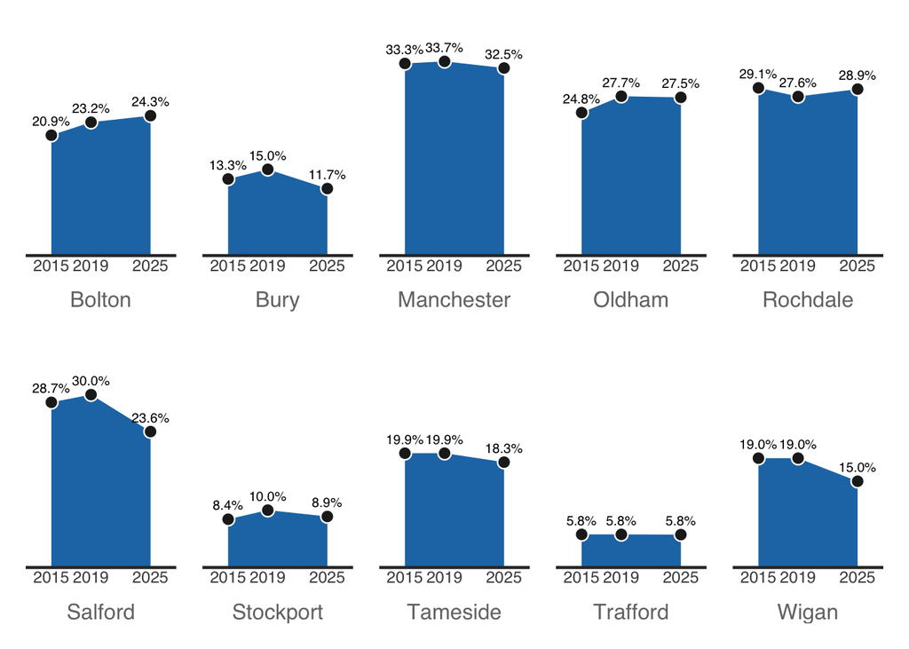

###### Source: English Indices of Deprivation, MHCLG | @traffordDataLab

#### CIPFA

#### Change in percentage of LSOAs in 1st decile of Employment domain, CIPFA statistical neighbours

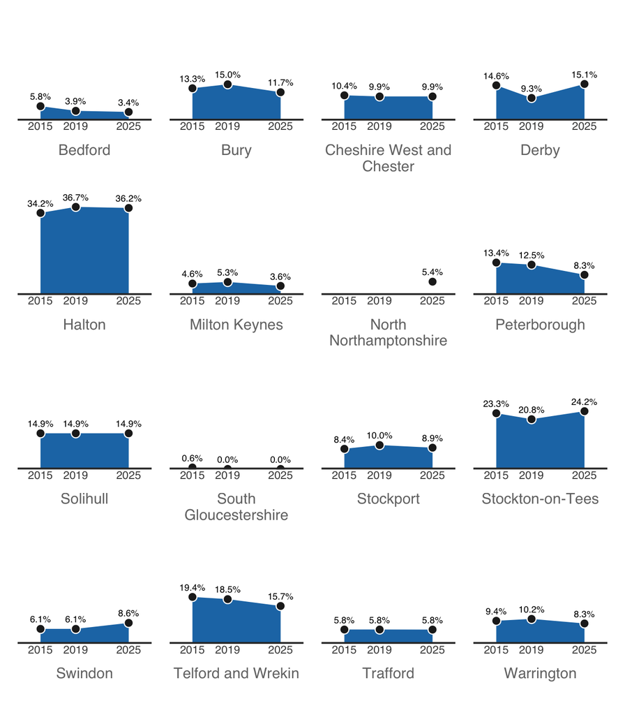

###### Source: English Indices of Deprivation, MHCLG | @traffordDataLab

#### NHS Peers

#### Change in percentage of LSOAs in 1st decile of Employment domain, NHS Near Neighbour peer group

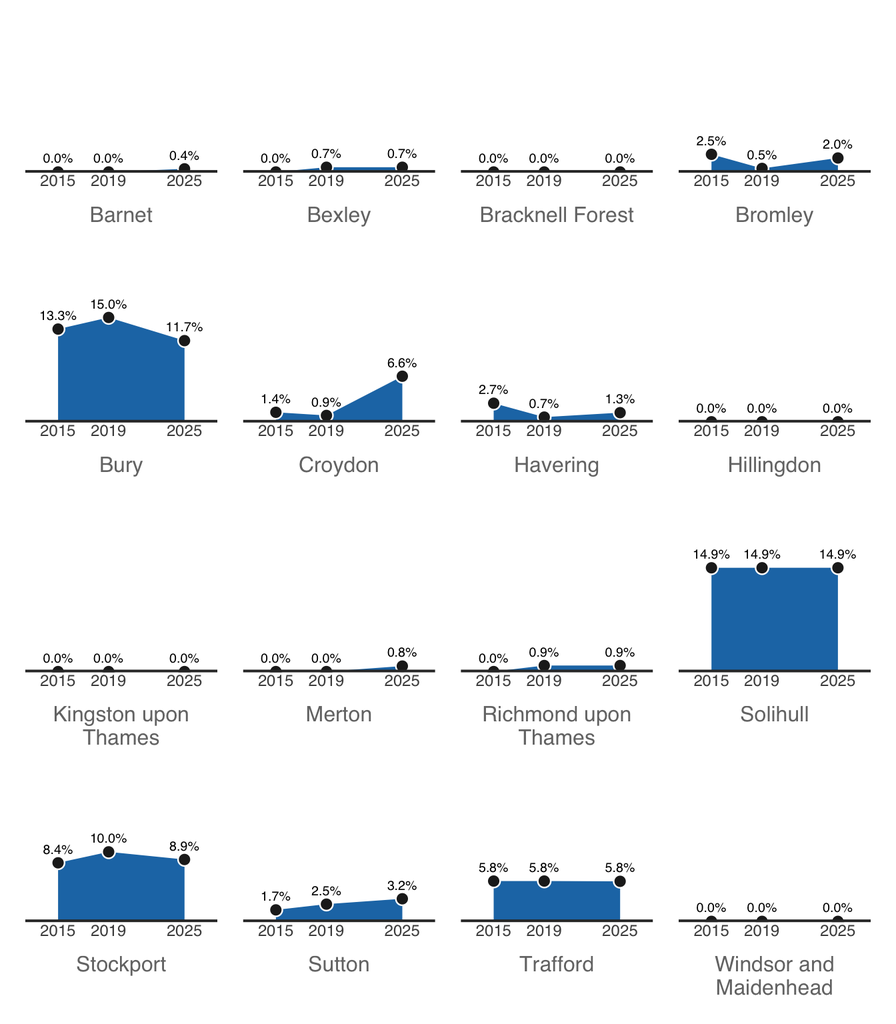

###### Source: English Indices of Deprivation, MHCLG | @traffordDataLab

2 LSOA in Bucklow-St Martins, 2 in Old Trafford, 2 in Manor, 1 in Longford and 1 in Timperley Central ward were amongst the 10% most deprived LSOAs on the Employment domain in England in 2025. 5 LSOAs sit within the 5% most deprived LSOAs nationally.

Trafford 017E in Bucklow-St Martins ward ranks 196 out of 33,755 LSOAs nationally with 41.5% of working-age residents involuntarily excluded from the labour market. In 2019, the same LSOA was ranked 572 out of 32,844 LSOAs nationally with 28.9% of residents involuntarily excluded from the labour market.

#### Employment domain 2025, LSOAs in Trafford

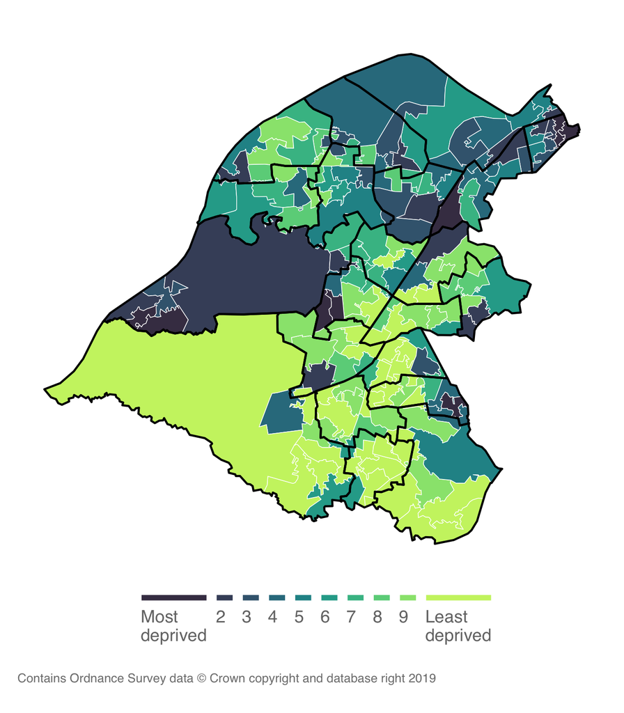

| LSOA | Ward | Decile | Rank |
| --- | --- | --- | --- |
| E01006108 | Bucklow-St Martins | 1 | 196 |
| E01006105 | Bucklow-St Martins | 1 | 470 |
| E01006168 | Manor | 1 | 800 |
| E01006109 | Old Trafford | 1 | 951 |
| E01006167 | Manor | 1 | 1,119 |
| E01006207 | Timperley Central | 1 | 1,926 |
| E01006144 | Longford | 1 | 2,434 |
| E01006112 | Old Trafford | 1 | 3,287 |

Source: English Indices of Deprivation (2025), MHCLG | @traffordDataLab

#### Employment deprivation 2025, LSOAs in Trafford

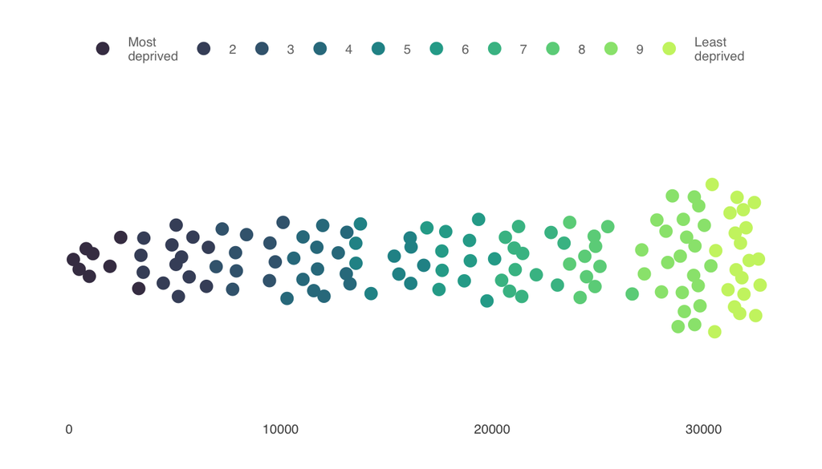

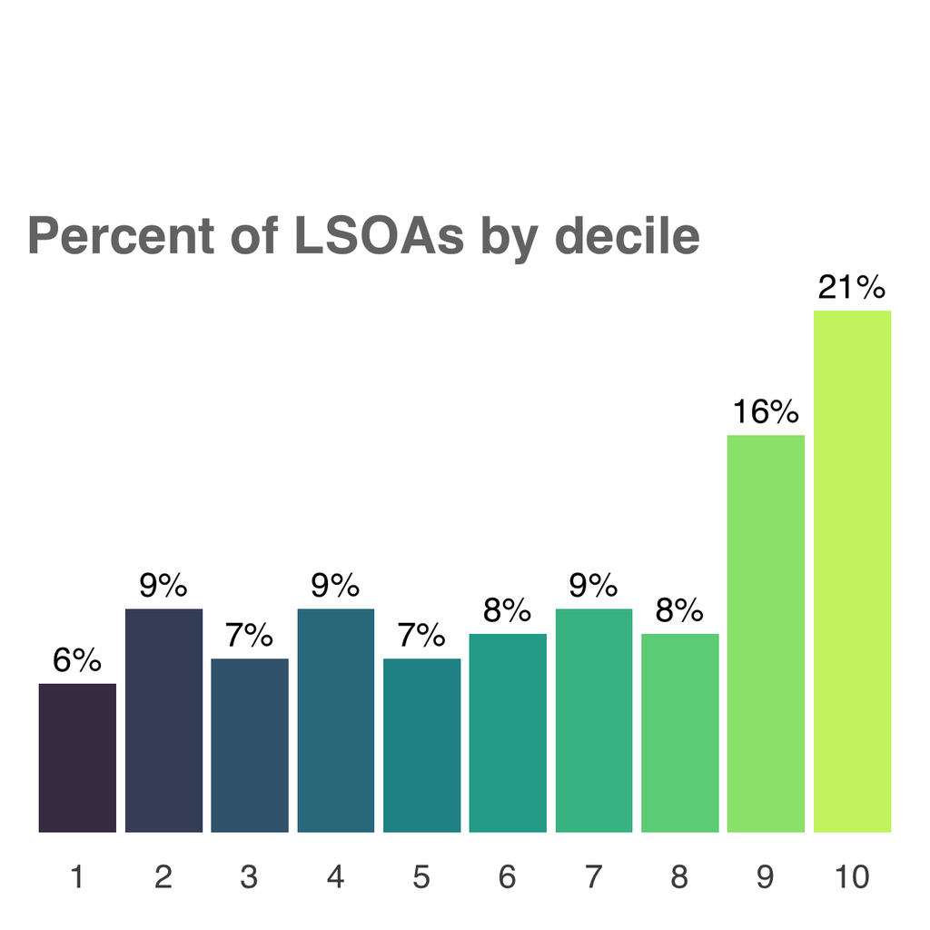

1 is most deprived  
Source: English Indices of Deprivation (2025), MHCLG | @traffordDataLab

The difference between the rank of the most deprived LSOA (196) and the least deprived LSOA (33584) on the Index of Multiple Deprivation is 33388

22.3 % of the LSOAs in Trafford are among the 3 most deprived deciles in England, 44.6 % of the LSOAs in Trafford are among the 3 least deprived deciles in England

## Education, Skills and Training

The Education, Skills and Training domain measures the lack of attainment and skills in the local population.

Trafford is ranked 276 out of 296 local authorities in England on the average 2025 Education, Skills and Training domain score. Trafford’s relative position was 275 out of 317 local authorities in 2019.

Click the tabs below for:

#### GM

#### Relative change in rank of average Education, Skills and Training score, GM authorities

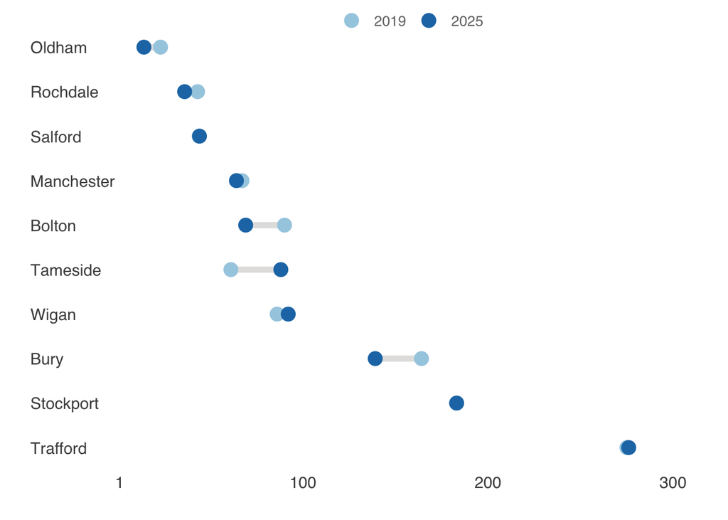

| Local authority | 2019 | 2025 | Change |
| --- | --- | --- | --- |
| Oldham | 23 | 14 | -9 |
| Rochdale | 43 | 36 | -7 |
| Salford | 44 | 44 | 0 |
| Manchester | 67 | 64 | -3 |
| Bolton | 90 | 69 | -21 |
| Tameside | 61 | 88 | 27 |
| Wigan | 86 | 92 | 6 |
| Bury | 164 | 139 | -25 |
| Stockport | 183 | 183 | 0 |
| Trafford | 275 | 276 | 1 |

Source: English Indices of Deprivation, MHCLG | @traffordDataLab

#### CIPFA

#### Relative change in rank of average Education, Skills and Training score, CIPFA statistical neighbours

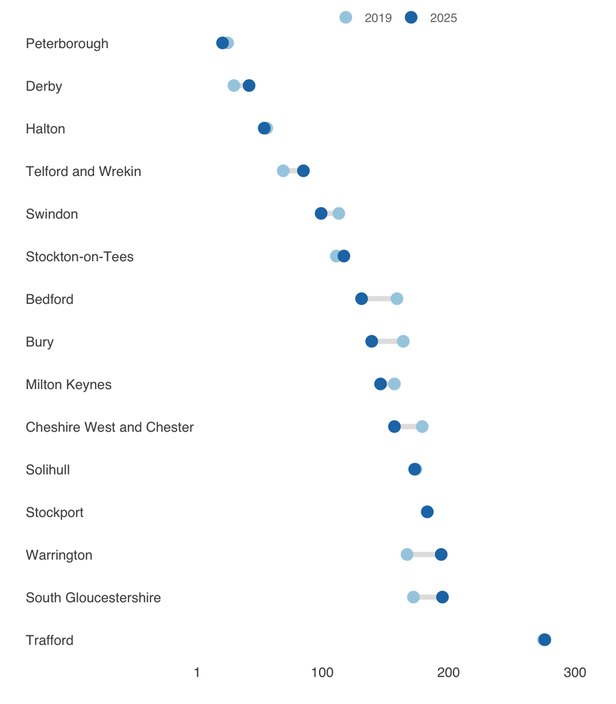

| Local authority | 2019 | 2025 | Change |
| --- | --- | --- | --- |
| Peterborough | 25 | 21 | -4 |
| Derby | 30 | 42 | 12 |
| Halton | 56 | 54 | -2 |
| North Northamptonshire | NA | 83 | NA |
| Telford and Wrekin | 69 | 85 | 16 |
| Swindon | 113 | 99 | -14 |
| Stockton-on-Tees | 111 | 117 | 6 |
| Bedford | 159 | 131 | -28 |
| Bury | 164 | 139 | -25 |
| Milton Keynes | 157 | 146 | -11 |
| Cheshire West and Chester | 179 | 157 | -22 |
| Solihull | 174 | 173 | -1 |
| Stockport | 183 | 183 | 0 |
| Warrington | 167 | 194 | 27 |
| South Gloucestershire | 172 | 195 | 23 |
| Trafford | 275 | 276 | 1 |

Source: English Indices of Deprivation, MHCLG | @traffordDataLab

#### NHS Peers

#### Relative change in rank of average Education, Skills and Training score, NHS Near Neighbour peer group

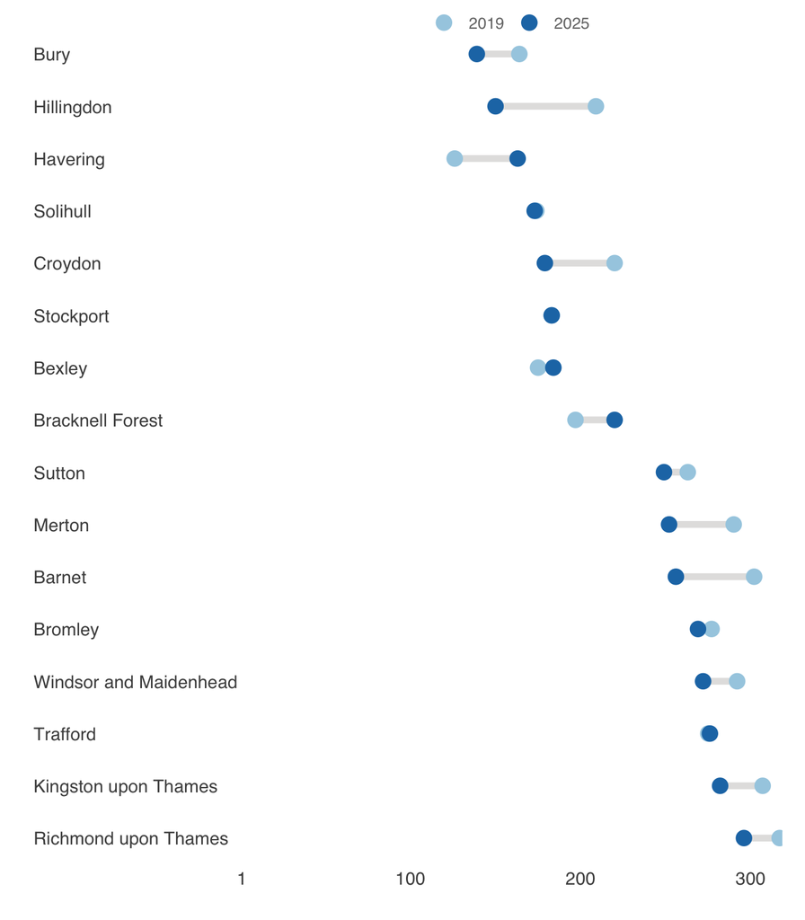

| Local authority | 2019 | 2025 | Change |
| --- | --- | --- | --- |
| Bury | 164 | 139 | -25 |
| Hillingdon | 209 | 150 | -59 |
| Havering | 126 | 163 | 37 |
| Solihull | 174 | 173 | -1 |
| Croydon | 220 | 179 | -41 |
| Stockport | 183 | 183 | 0 |
| Bexley | 175 | 184 | 9 |
| Bracknell Forest | 197 | 220 | 23 |
| Sutton | 263 | 249 | -14 |
| Merton | 290 | 252 | -38 |
| Barnet | 302 | 256 | -46 |
| Bromley | 277 | 269 | -8 |
| Windsor and Maidenhead | 292 | 272 | -20 |
| Trafford | 275 | 276 | 1 |
| Kingston upon Thames | 307 | 282 | -25 |
| Richmond upon Thames | 317 | 296 | -21 |

Source: English Indices of Deprivation, MHCLG | @traffordDataLab

The proportion of Trafford’s LSOAs ranked in the 1st decile or 10% most deprived in England was 1.4% (2 out of 139) in 2025. This represents practically no change since 2019 when 1.5% (2 out of 138) of LSOAs were ranked within the 1st decile.

Click the tabs below for:

#### GM

#### Change in percentage of LSOAs in 1st decile of Education, Skills and Training domain, GM authorities

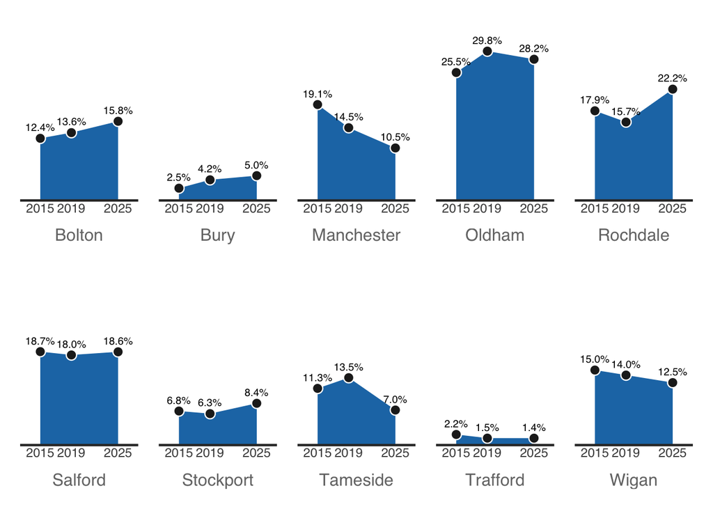